# R Notebook

```
library(tidyverse)
library(datasets)
library(MASS)
library(car)
library(leaps)
swiss<-swiss
```

### Question 1

In this question, you will revisit the swiss data set that you worked on in Homeworks 6 and 7. The data set contains information regarding a standardized fertility measure and socio-economic indictors for each of the 47 French-speaking provinces of Switzerland around the year 1888. In Homework 5, you found that the model with just three predictors: Education, Catholic, and Infant Mortality was preferred to a model with all the predictors. Fit the model with the three predictors, and answer the following questions.

```
mlr<-lm(Fertility ~ Education + Catholic + Infant.Mortality, data=swiss)
```

#### A

Are there any outlier observations?

Plotting the residual plots as well as individual variable plots for a better visualization of what is going on with the data.

```
plot(mlr)
```

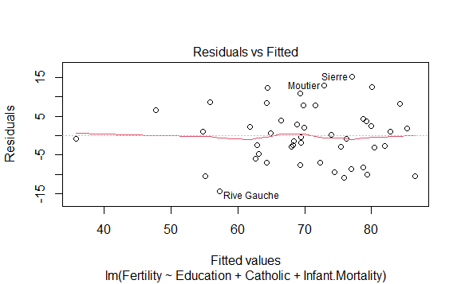

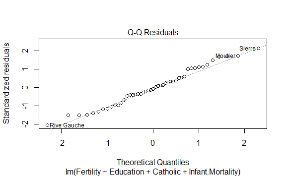

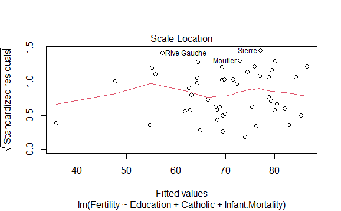

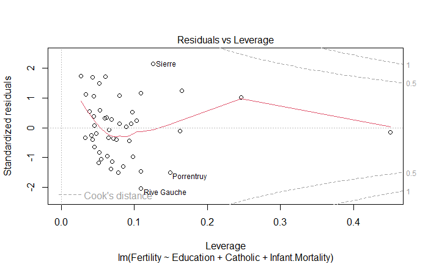

```
avPlots(mlr)
```

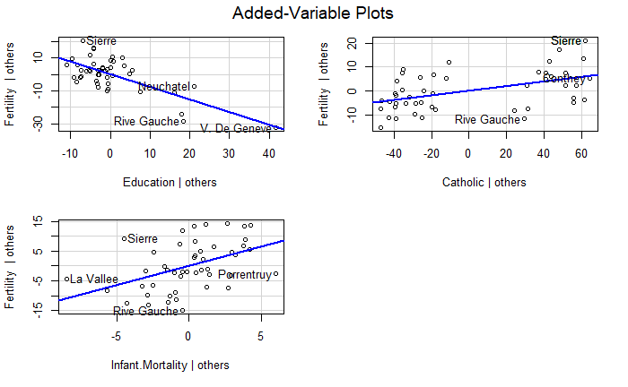

```
##externally studentized variables for leverage and outliers
hii<- lm.influence(mlr)$hat # leverages
ext.student<- rstudent(mlr) # externalized student residuals
n<- nrow(swiss)
p<- 4 # 4 total parameters
```

Theses will allow us to begin assessing for leverage and outliers

```
sort(ext.student[abs(ext.student)])
```

```
  Delemont   Delemont Courtelary Courtelary Courtelary Courtelary
 0.5885021  0.5885021  1.5141373  1.5141373  1.5141373  1.5141373
Courtelary Courtelary Courtelary Courtelary Courtelary Courtelary
 1.5141373  1.5141373  1.5141373  1.5141373  1.5141373  1.5141373
Courtelary Courtelary Courtelary Courtelary Courtelary Courtelary
 1.5141373  1.5141373  1.5141373  1.5141373  1.5141373  1.5141373
Courtelary Courtelary
 1.5141373  1.5141373
```

In general, an observation is classified as an outlier when |ti|>3, none of these observations meet the critera

```
sort(abs(cooks.distance(mlr))>=1)
```

```
  Courtelary     Delemont Franches-Mnt      Moutier   Neuveville
       FALSE        FALSE        FALSE        FALSE        FALSE
  Porrentruy        Broye        Glane      Gruyere       Sarine
       FALSE        FALSE        FALSE        FALSE        FALSE
     Veveyse        Aigle      Aubonne     Avenches     Cossonay
       FALSE        FALSE        FALSE        FALSE        FALSE
   Echallens     Grandson     Lausanne    La Vallee       Lavaux
       FALSE        FALSE        FALSE        FALSE        FALSE
      Morges       Moudon        Nyone         Orbe         Oron
       FALSE        FALSE        FALSE        FALSE        FALSE
     Payerne Paysd'enhaut        Rolle        Vevey      Yverdon
       FALSE        FALSE        FALSE        FALSE        FALSE
     Conthey    Entremont       Herens     Martigwy      Monthey
       FALSE        FALSE        FALSE        FALSE        FALSE
  St Maurice       Sierre         Sion       Boudry La Chauxdfnd
       FALSE        FALSE        FALSE        FALSE        FALSE
    Le Locle    Neuchatel   Val de Ruz ValdeTravers V. De Geneve
       FALSE        FALSE        FALSE        FALSE        FALSE
 Rive Droite  Rive Gauche
       FALSE        FALSE
```

Following this, no data falls under the category of having a cook’s distance greater than 1, another general rule that would say that a observation has undue influence over the model maybe suggesting it to be an outlier.

#### B

```
##comparing data to look for high leverage
hii[hii>2*p/n]
```

```
   La Vallee V. De Geneve
   0.2461056    0.4501392
```

2 observations have high leverage, those from La Vallee V. and Fe Geneve.

```
sort(hii)
```

```
     Moutier La Chauxdfnd     Le Locle       Boudry ValdeTravers
  0.02661704   0.03286437   0.03382830   0.03871182   0.04088238
      Lavaux   Neuveville     Grandson   Val de Ruz       Morges
  0.04284048   0.04285277   0.04415246   0.04468945   0.04503096
       Vevey      Aubonne    Echallens   Courtelary        Nyone
  0.04544170   0.04770628   0.05112156   0.05193009   0.05242355
    Delemont     Cossonay        Aigle Franches-Mnt      Gruyere
  0.05297992   0.05493888   0.05924589   0.06010649   0.06242374
     Yverdon        Rolle     Avenches    Entremont Paysd'enhaut
  0.06315748   0.06499491   0.06538567   0.06840751   0.06842411
    Martigwy      Monthey         Oron       Moudon        Broye
  0.06973133   0.07141262   0.07541899   0.07812621   0.07933908
        Sion   St Maurice      Payerne       Herens     Lausanne
  0.07965007   0.08480751   0.08869935   0.09287236   0.09591096
      Sarine         Orbe      Veveyse        Glane  Rive Droite
  0.09730273   0.09772627   0.10276388   0.10872122   0.10900165
 Rive Gauche       Sierre   Porrentruy      Conthey    Neuchatel
  0.10906673   0.12578918   0.14876552   0.16245603   0.16503569
   La Vallee V. De Geneve
  0.24610559   0.45013921
```

These observations are both quite a bit higher than the next closest ones; however, I would assert that De Geneve has higher leverage on the model than La Vallee V.

#### C

```
### measuring for observational influence based on DFFITS
fits<-dffits(mlr)
sort(abs(fits) >= 2*sqrt(p/n))
```

```
  Courtelary     Delemont Franches-Mnt      Moutier   Neuveville
       FALSE        FALSE        FALSE        FALSE        FALSE
       Broye        Glane      Gruyere       Sarine      Veveyse
       FALSE        FALSE        FALSE        FALSE        FALSE
       Aigle      Aubonne     Avenches     Cossonay    Echallens
       FALSE        FALSE        FALSE        FALSE        FALSE
    Grandson     Lausanne    La Vallee       Lavaux       Morges
       FALSE        FALSE        FALSE        FALSE        FALSE
      Moudon        Nyone         Orbe         Oron      Payerne
       FALSE        FALSE        FALSE        FALSE        FALSE
Paysd'enhaut        Rolle        Vevey      Yverdon      Conthey
       FALSE        FALSE        FALSE        FALSE        FALSE
   Entremont       Herens     Martigwy      Monthey   St Maurice
       FALSE        FALSE        FALSE        FALSE        FALSE
        Sion       Boudry La Chauxdfnd     Le Locle    Neuchatel
       FALSE        FALSE        FALSE        FALSE        FALSE
  Val de Ruz ValdeTravers V. De Geneve  Rive Droite   Porrentruy
       FALSE        FALSE        FALSE        FALSE         TRUE
      Sierre  Rive Gauche
        TRUE         TRUE
```

Based on the outcome of DFFITS there are 3 influential observations: - Porrentruy - Sierre - Rive Gauche

Following this, as shown in part of the support for the answer for question 1, there are no observations classified as influential according to Cook’s Distance.

#### D

The difference between the evaluation of Influence based on DFFITS and Cook’s Distance is one (DFFITS) measures the influence an observation has on its own fitted value, and how many standard errors the fitted value changes with this observation being removed from the calculation of the model. Cook’s Distance instead measures the Euclidean distance squared, the distance when graphed, between the vector of the fitted values with an without a specific observation. In simpler terms, it compares the slope in relative graphed space and how different the square of these distances are with and without an observation in turn measuring the influence of that value on all fitted values rather than just its influence on its own point.